# DATA VISUALIZATION FINAL PROJECT

Owayne Owens

2022-09-17

The data that informs this project was taken from the FBI Data Explorer Website: (https://crime-data-explorer.app.cloud.gov/pages/explorer/crime/hate-crime)

## HATE CRIME IN THE US AND A CLOSER LOOK AT THE STATE OF VIRGINIA

The FBI Uniform Crime Reporting Program defines hate crime as a committed criminal offense which is motivated, in whole or in part, by the offender’s bias(es) against a race, religion, disability, sexual orientation, ethnicity, gender, or gender identity. Because motivation is subjective, it is sometimes difficult to know with certainty whether a crime resulted from the offender’s bias. The presence of bias alone does not necessarily mean that a crime can be considered a hate crime. Only when a law enforcement investigation reveals sufficient evidence to lead a reasonable and prudent person to conclude that the offender’s actions were motivated, in whole or in part, by their bias, should an agency report an incident as a hate crime.

The aim of this project is to use FBI data to see how hate crimes vary across race in the State of Virginia from 2015 to 2020. I am interested in investigating if there are any disparities for a certain races as it relates to 4 specific forms of hate crimes: Aggravted Assualt, Intimidation, Robbery, and Simple Assualt from 2016 to 2020.

## PIE CHART

Here’s a quick look at the distribution of Hate Crimes across race in Virginia.

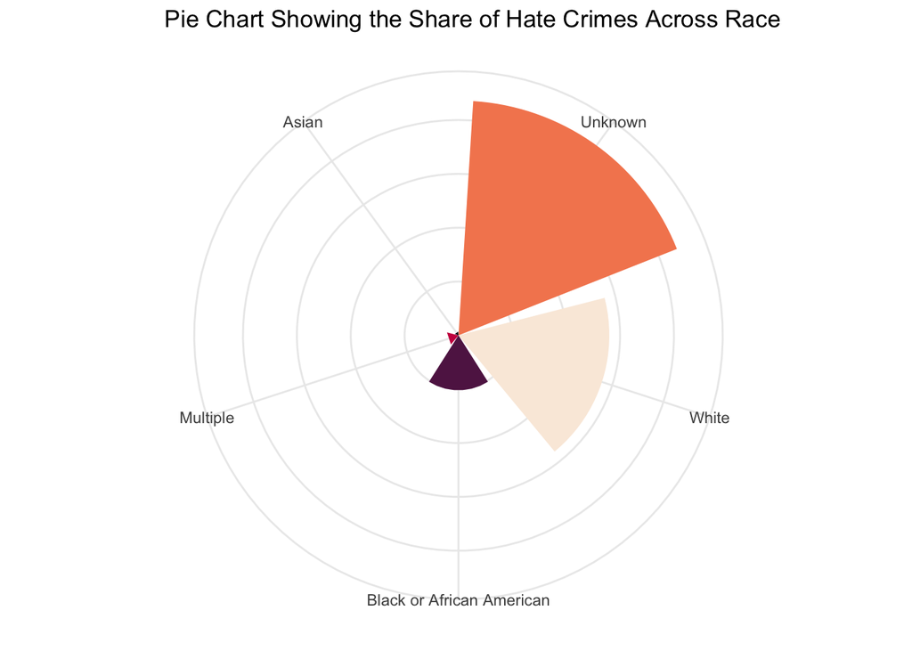

```r
#pie chart showing share of hate crimes by race
hate_crime %>%
filter(data_year > 2015 & offender_race != "NA" &
         offender_race != "Native Hawaiian or Other Pacific Islander"
       & state_name == "Virginia") %>%
    ggplot(aes(x= fct_infreq(offender_race), fill = offender_race)) +
    geom_bar() +
    coord_polar()+
    scale_fill_viridis_d(option = "rocket") +
    theme_minimal()+
    theme(axis.line = element_blank(), axis.title = element_blank(), axis.ticks = element_blank(),
          axis.text.y = element_blank())+
    labs(title = "Pie Chart Showing the Share of Hate Crimes Across Race")+
    guides(fill = "none")
```

## BAR GRAPH

To get an idea of what the numbers looked like, this bar graph shows the recorded number of hate crimes for each race category. As was evident in the pie chart, White and Unknown races are the most dominant among hate crimes in the state of Virginia. They have little less than 300 and a little over 400 counts, respectively.

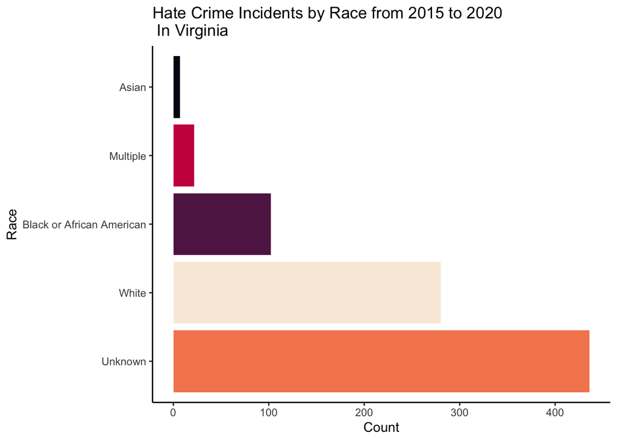

```r
#bar graph showing hate crimes by race
hate_crime %>%
filter(data_year > 2015 & offender_race != "NA" &
       offender_race != "Native Hawaiian or Other Pacific Islander"
       & state_name == "Virginia") %>%
  ggplot(aes(y = fct_infreq(offender_race), fill = offender_race)) +
  geom_bar() +
  theme_minimal() +
  scale_fill_viridis_d(option = "rocket") +
  theme_classic() +
  guides(fill = "none") +
  labs(title = "Hate Crime Incidents by Race from 2015 to 2020\n In Virginia",
       x = "Count",
       y = "Race")
```

## STACKED BAR GRAPH

To further investigate the data, I wanted to see how race was represented across the 4 main kinds of hate crimes. This stacked bar graph shows how the recorded number of these hate crimes varied by race. White and Unknown races were overrepresented in these categories as well, except for simple assault where the Black race category dominated Unknown.

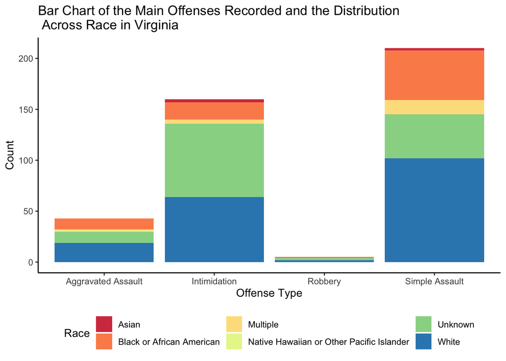

```r
tmp %>%
  ggplot(aes(x = offense_name, fill = offender_race, y = count))+
  geom_col()+
  theme_minimal() +
  theme_classic() +
  theme(legend.position = "bottom")+
  scale_fill_brewer(palette = "Spectral")+
  labs(title = "Bar Chart of the Main Offenses Recorded and the Distribution\n Across Race in Virginia",
       x = "Offense Type",
       y = "Count",
       fill = "Race")
```

## LINE GRAPH

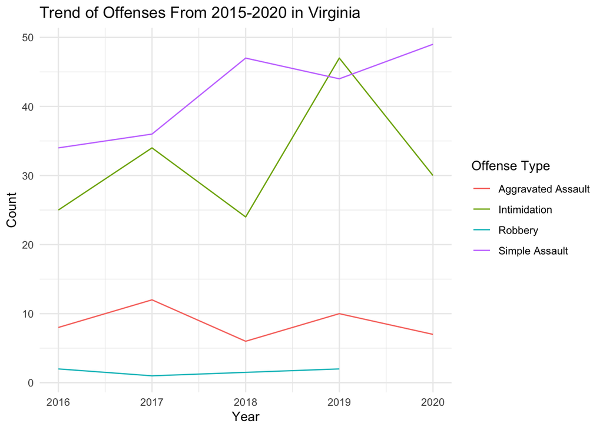

```r
odm %>%
  ggplot(aes(x = data_year, y = count, color = offense_name, fill = offense_name))+
  geom_line()+
  theme_minimal()+
  labs(color = "Offense Type",
       x = "Year",
       y = "Count",
       title = "Trend of Offenses From 2015-2020 in Virginia")
```

## DATA TABLE

If you are interested in other demographic features that were not presented in the diagrams about, for example: bias and victim types. You can use this table as a resource to explore that data.

```r
#data table for hate crimes in Virginia
hate_crime%>%
  filter(data_year > 2015 & state_name == "Virginia") %>%
  select(c(8, 2, 6, 19, 22, 25, 26)) %>%
  datatable(colnames = c("State", "Year", "Agency Type", "Offender Race", "Offense Description", "Bias Type",
                         "Victim Type"),
            caption = "FBI data on hate crimes in Virginia")
```

|  | State | Year | Agency Type | Offender Race | Offense Description | Bias Type | Victim Type |
| --- | --- | --- | --- | --- | --- | --- | --- |
| 1 | Virginia | 2016 | County | White | Simple Assault | Anti-Mental Disability | Individual |
| 2 | Virginia | 2016 | County | White | Simple Assault | Anti-Mental Disability | Individual |
| 3 | Virginia | 2016 | University or College | Unknown | Intimidation | Anti-Gay (Male) | Individual |
| 4 | Virginia | 2016 | County | White | Intimidation | Anti-Black or African American | Individual |
| 5 | Virginia | 2016 | County | Multiple | Simple Assault | Anti-Black or African American | Individual |
| 6 | Virginia | 2016 | County | Unknown | Destruction/Damage/Vandalism of Property | Anti-Lesbian, Gay, Bisexual, or Transgender (Mixed Group) | Individual |
| 7 | Virginia | 2016 | County | Black or African American | Simple Assault | Anti-White | Individual |
| 8 | Virginia | 2016 | County | White | Simple Assault | Anti-Asian | Individual |
| 9 | Virginia | 2016 | County | Unknown | Destruction/Damage/Vandalism of Property | Anti-Black or African American | Business |
| 10 | Virginia | 2016 | County | Unknown | Destruction/Damage/Vandalism of Property | Anti-Jewish | Business |

[output cut: 839 more lines]

## CHOROPLETH

It was evident that among hate crimes in Virginia, White and Unknown races seem to be the most active. When we looked closer at the 4 specific categories (Simple Assault, Aggravated Assault, Robbery, and Intimidation), we saw the same pattern of White and Unknown being the dominant races, except for Simple assault, where the Black race category had a bigger share than Unknown.

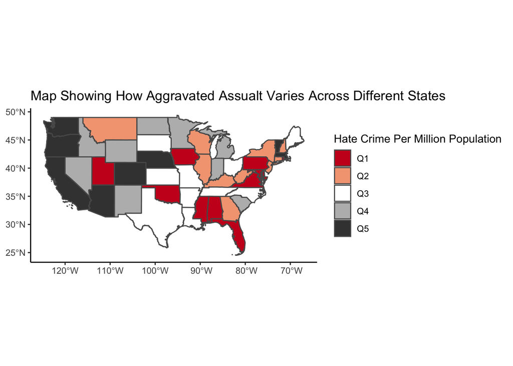

```r
state_hc_pop_geo %>% # filter to just lower 48 states and for one kind of offense
  filter(!GEOID %in% c("60", "66", "69", "72", "78", "02", "15"),
         offense_name == "Aggravated Assault") %>%
  mutate(crime_rate_bin = factor(ntile(crime_rate, 5),
                                 labels = c("Q1", "Q2", "Q3", "Q4", "Q5"))) %>%
  ggplot() +
  geom_sf(aes(fill = crime_rate_bin))+
  scale_fill_brewer(palette = "RdGy")+
  theme_classic()+
  labs(title = "Map Showing How Aggravated Assualt Varies Across Different States",
       fill = "Hate Crime Per Million Population")
```